# 3. CDI-side word difficulty (IRT) and child ability

peekbank-items

The naive linking analyses (notebook 2) used **Wordbank AoA** as the word difficulty measure, and it failed. AoA confounds a word’s difficulty with the age distribution of the norming sample and does not place words on a common latent scale relative to child ability.

Here we fit a lightweight **2PL IRT** model to Wordbank produces data. This gives, for each word, a difficulty `b` and discrimination `a` on a latent ability scale, plus a bridge from a child’s CDI sum score to their latent ability `theta`. These are the CDI-side ingredients for the linking analyses.

```r
library(here)
library(mirt)
library(wordbankr)
source(here("helper", "common.R"))
knitr::opts_chunk$set(cache = FALSE)
```

## Pull Wordbank data

English (American) WS produces (the large single-form matrix used for the IRT fit) and WG produces (added only for the AoA comparison, which benefits from younger children).

```r
wb_path <- here("cached_intermediates", "3_wordbank_raw.rds")
if (!file.exists(wb_path)) {
  ws_data <- get_instrument_data(language = "English (American)", form = "WS",
                                 administration_info = TRUE, item_info = TRUE)
  wg_data <- get_instrument_data(language = "English (American)", form = "WG",
                                 administration_info = TRUE, item_info = TRUE)
  saveRDS(list(ws = ws_data, wg = wg_data), wb_path)
}
wb <- readRDS(wb_path)
ws_data <- wb$ws
wg_data <- wb$wg
```

## Fit 2PL on WS produces

Build a child × item response matrix over word items and fit a 2PL.

```r
irt_path <- here("cached_intermediates", "3_irt_2pl.rds")

ws_words <- ws_data |>
  filter(item_kind == "word") |>
  mutate(produces = as.integer(value == "produces")) |>
  select(data_id, item_definition, produces)

resp_mat <- ws_words |>
  pivot_wider(names_from = item_definition, values_from = produces) |>
  column_to_rownames("data_id") |>
  as.matrix()

if (!file.exists(irt_path)) {
  mod_2pl <- mirt(resp_mat, model = 1, itemtype = "2PL", verbose = FALSE)
  saveRDS(mod_2pl, irt_path)
}
mod_2pl <- readRDS(irt_path)

# item parameters: a (discrimination), b (difficulty) on the IRT metric
item_pars <- coef(mod_2pl, IRTpars = TRUE, simplify = TRUE)$items |>
  as.data.frame() |>
  rownames_to_column("item_definition") |>
  as_tibble() |>
  mutate(item = str_to_lower(item_definition))

item_pars |> arrange(b) |> select(item, a, b) |> head(15) |> kable(digits = 2)
```

| item | a | b |
| --- | --- | --- |
| daddy* | 1.00 | -3.20 |
| mommy* | 1.07 | -3.20 |
| uh oh | 0.97 | -2.33 |
| bye | 1.43 | -2.05 |
| ball | 2.21 | -1.95 |
| no | 1.55 | -1.73 |
| dog | 1.62 | -1.60 |
| hi | 1.28 | -1.50 |
| woof woof | 1.18 | -1.46 |
| moo | 1.36 | -1.42 |
| baby | 1.87 | -1.31 |
| banana | 1.91 | -1.26 |
| grrr | 0.79 | -1.23 |
| shoe | 2.45 | -1.22 |
| meow | 1.51 | -1.21 |

```r
item_pars |> arrange(desc(b)) |> select(item, a, b) |> head(15) |> kable(digits = 2)
```

| item | a | b |
| --- | --- | --- |
| country | 2.31 | 2.56 |
| hate | 1.92 | 2.47 |
| walker | 1.73 | 2.46 |
| an | 1.97 | 2.43 |
| each | 2.39 | 2.39 |
| if | 2.13 | 2.36 |
| would | 2.57 | 2.35 |
| yourself | 2.38 | 2.35 |
| downtown | 1.80 | 2.35 |
| which | 2.18 | 2.27 |
| basement | 1.40 | 2.20 |
| play pen | 1.77 | 2.19 |
| could | 2.39 | 2.19 |
| poor | 2.29 | 2.19 |
| about | 2.48 | 2.17 |

## Sum score → latent ability bridge

Peekbank gives us a child’s CDI **sum score**, not item responses. We invert the test characteristic curve (expected sum score as a function of `theta`) to map any WS sum score (or proportion) to a latent ability `theta`.

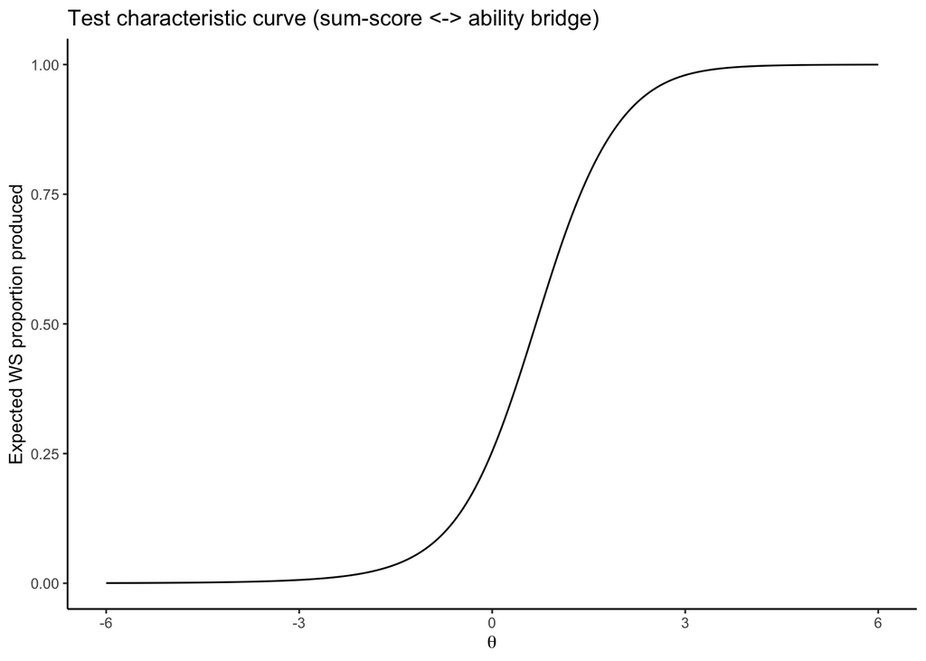

```r
theta_grid <- seq(-6, 6, by = 0.05)
# expected score: sum over items of P(produces | theta)
exp_scores <- expected.test(mod_2pl, matrix(theta_grid, ncol = 1))
n_items <- ncol(resp_mat)

bridge <- tibble(theta = theta_grid,
                 expected_sum = exp_scores,
                 expected_prop = exp_scores / n_items)

ggplot(bridge, aes(x = theta, y = expected_prop)) +
  geom_line() +
  ylab("Expected WS proportion produced") +
  xlab(expression(theta)) +
  ggtitle("Test characteristic curve (sum-score <-> ability bridge)")
```

```r
# function: WS proportion -> theta (monotone interpolation)
prop_to_theta <- approxfun(bridge$expected_prop, bridge$theta, rule = 2)
```

## Compare IRT difficulty to Wordbank AoA

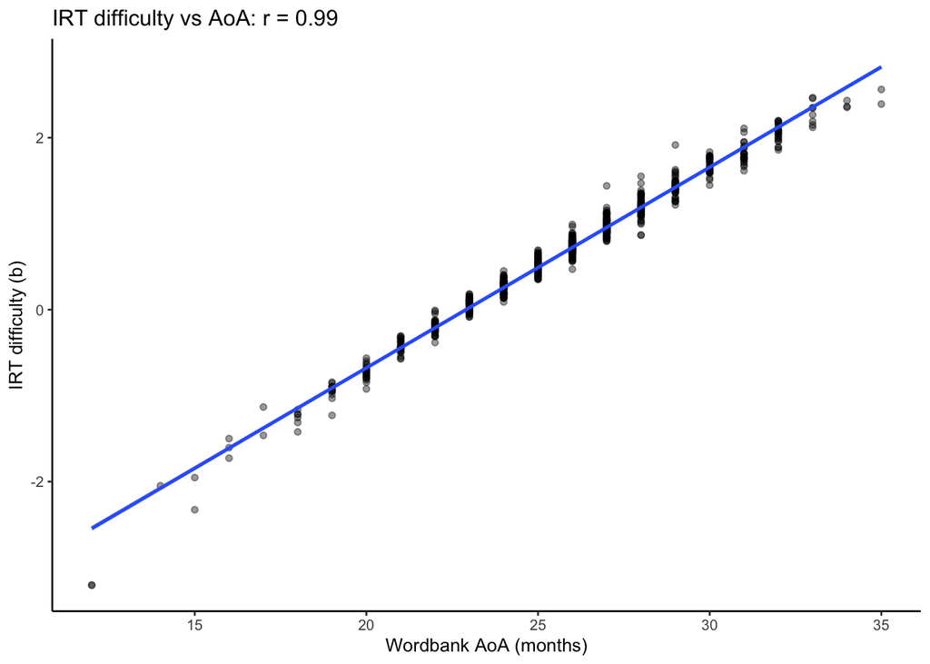

```r
aoa_path <- here("cached_intermediates", "3_aoas.rds")
if (!file.exists(aoa_path)) {
  ws_item_ids <- ws_data |> select(item_id, item_definition, item_kind) |> distinct()
  wg_data_ws_ids <- wg_data |> select(-item_id) |> left_join(ws_item_ids)
  wordbank_data <- bind_rows(ws_data, wg_data_ws_ids) |>
    mutate(form = "both") |> filter(item_kind == "word")
  aoas <- fit_aoa(wordbank_data, measure = "produces", method = "glmrob",
                  age_min = 8, age_max = 36)
  saveRDS(aoas, aoa_path)
}
aoas <- readRDS(aoa_path) |>
  ungroup() |>
  select(item_definition, aoa) |>
  mutate(item = str_to_lower(item_definition))

difficulty <- item_pars |>
  select(item, a, b) |>
  inner_join(aoas |> select(item, aoa), by = "item")

ggplot(difficulty, aes(x = aoa, y = b)) +
  geom_point(alpha = .4) +
  geom_smooth(method = "lm") +
  xlab("Wordbank AoA (months)") +
  ylab("IRT difficulty (b)") +
  ggtitle(sprintf("IRT difficulty vs AoA: r = %.2f",
                  cor(difficulty$aoa, difficulty$b, use = "complete.obs")))
```

IRT difficulty and AoA are correlated but not identical — AoA additionally reflects the sample age distribution, while `b` is on the latent ability metric.

## Save CDI-side measures

```r
saveRDS(
  list(
    item_pars = item_pars,          # a, b per word
    aoas = aoas,                    # Wordbank AoA per word
    bridge = bridge,                # theta <-> expected WS prop
    prop_to_theta = prop_to_theta,  # function: WS prop -> theta
    n_ws_items = n_items
  ),
  here("cached_intermediates", "3_cdi_difficulty.Rds")
)
```